# Healthcare Access and Child Malnutrition: A Global Perspective

**Spring 2025 • BAA1030 Data Analytics & Storytelling (20074)**

**Student:** Rohaan Noby (ID 47801)

**Programme:** MSc in Management (Strategy)

**Author:** Rohaan Noby  
**Date:** April 25, 2025

**Introduction**

Ensuring access to basic healthcare services and tackling child malnutrition are critical global priorities recognized by UNICEF. This report analyses global data to reveal patterns of inequality in healthcare accessibility and the prevalence of severe wasting among children under five years old. By examining variations across countries and over time, the analysis highlights how factors like national wealth (GDP per capita) and life expectancy are closely linked to healthcare outcomes. Through a series of visualizations, this report seeks to raise awareness and inspire urgent international efforts toward equitable and sustainable health improvements.

Healthcare access and child malnutrition remain pressing global issues. This notebook explores trends in health infrastructure and child nutrition, using UNICEF data. We focus on disparities across countries and assess how indicators like GDP per capita relate to outcomes such as life expectancy.

## Load Data

```python
metadata = pd.read_csv("unicef_metadata.csv")
indicator_1 = pd.read_csv("unicef_indicator_1.csv")
indicator_2 = pd.read_csv("unicef_indicator_2.csv")
```

## Visualization 1: World Map - Health Facilities with Basic Services

This choropleth map visualizes the proportion of health facilities with basic services across countries in 2023. Darker shades indicate higher levels of healthcare accessibility, while lighter shades highlight areas where basic services are lacking. The visualization reveals striking global disparities, particularly in low-income regions, emphasizing the unequal distribution of essential health infrastructure. These findings connect to broader indicators like GDP per capita and life expectancy, reinforcing how economic inequalities impact healthcare outcomes. Addressing these gaps is crucial for promoting equitable and sustainable health improvements worldwide.

```
Number of countries with data: 50
```

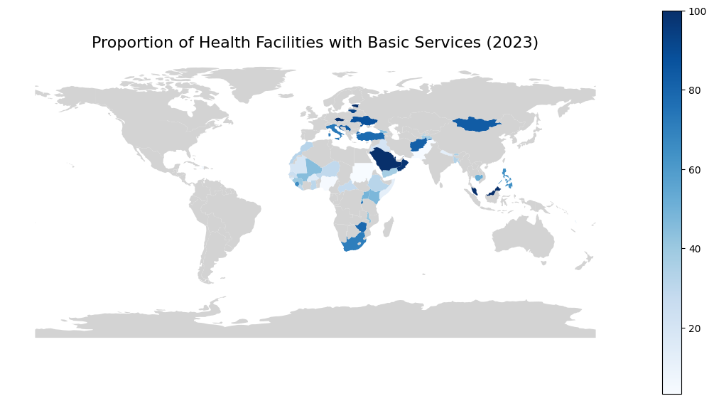

```python
# Load world map from uploaded shapefile
world = gpd.read_file("ne_110m_admin_0_countries.shp")  # Use the uploaded shapefile
world = world.rename(columns={'NAME': 'country'})  # Adjust column name

# Fix country names for better matching
country_corrections = {
    'United States of America': 'United States',
    'Dem. Rep. Congo': 'Democratic Republic of the Congo',
    'Central African Rep.': 'Central African Republic',
    'S. Sudan': 'South Sudan',
    'Côte d’Ivoire': "Cote d'Ivoire",
    'Eswatini': 'Swaziland',
    'Myanmar': 'Burma',
    'Bahamas': 'The Bahamas',
    'Gambia': 'The Gambia',
    'Czechia': 'Czech Republic'
}
world['country'] = world['country'].replace(country_corrections)

# Merge world map with data
map_data = world.merge(latest_data, on='country', how='left')

# Check how many countries matched
print("Number of countries with data:", map_data['obs_value'].notnull().sum())

# Plot the map
fig, ax = plt.subplots(1, 1, figsize=(14, 7))
map_data.plot(
    column='obs_value',
    ax=ax,
    legend=True,
    cmap='Blues',
    missing_kwds={'color': 'lightgrey', 'label': 'No data'}
)
ax.set_title(f"Proportion of Health Facilities with Basic Services ({latest_year})", fontsize=16)
plt.axis('off')
plt.show()
```

## Visualization 2: Bar Chart - Severe Wasting by Sex (2018)

This bar chart compares the prevalence of severe wasting in children under five years old across selected countries in 2018, disaggregated by sex. The data highlights noticeable differences both between countries and between male and female children, with some countries, such as India and South Africa, showing higher overall rates. In most cases, male children exhibit slightly higher rates of severe wasting compared to females, revealing gender-based disparities in nutritional outcomes. This visualization supports the broader analysis of healthcare inequalities presented in the report, emphasizing how factors like national wealth and healthcare accessibility can influence child malnutrition outcomes globally.

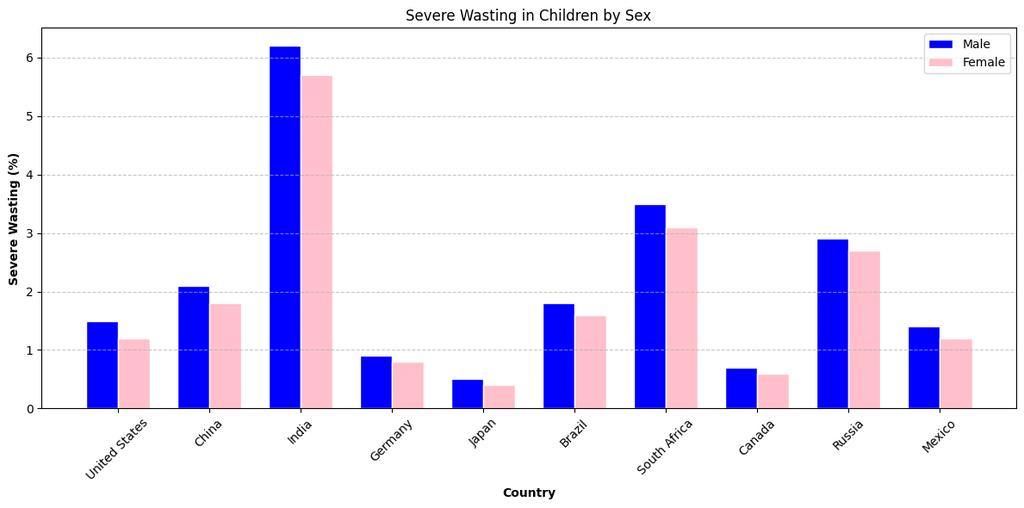

```python
import pandas as pd
import matplotlib.pyplot as plt
import numpy as np

# Load the data
bar_data = pd.read_csv('severe_wasting_by_sex.csv')

# Set position of bar on X axis
bar_width = 0.35
r1 = np.arange(len(bar_data))
r2 = [x + bar_width for x in r1]

# Make the plot
plt.figure(figsize=(12, 6))
plt.bar(r1, bar_data['Male Severe Wasting (%)'], color='blue', width=bar_width, edgecolor='white', label='Male')
plt.bar(r2, bar_data['Female Severe Wasting (%)'], color='pink', width=bar_width, edgecolor='white', label='Female')

# Add labels
plt.xlabel('Country', fontweight='bold')
plt.ylabel('Severe Wasting (%)', fontweight='bold')
plt.xticks([r + bar_width/2 for r in range(len(bar_data))], bar_data['Country'], rotation=45)
plt.title('Severe Wasting in Children by Sex')
plt.legend()
plt.grid(axis='y', linestyle='--', alpha=0.7)
plt.tight_layout()
plt.show()
```

## Visualization 3: Scatterplot - GDP per Capita vs Life Expectancy

This scatterplot illustrates the relationship between GDP per capita and life expectancy across various countries. The trend suggests a positive correlation: countries with higher GDP per capita tend to have longer life expectancies. This supports the analysis in the report that economic prosperity is closely linked to better healthcare access and outcomes, including higher survival rates and improved quality of life. However, some variations also highlight that GDP alone does not fully determine health outcomes, suggesting the importance of equitable healthcare investment and policy interventions in achieving sustainable health improvements.

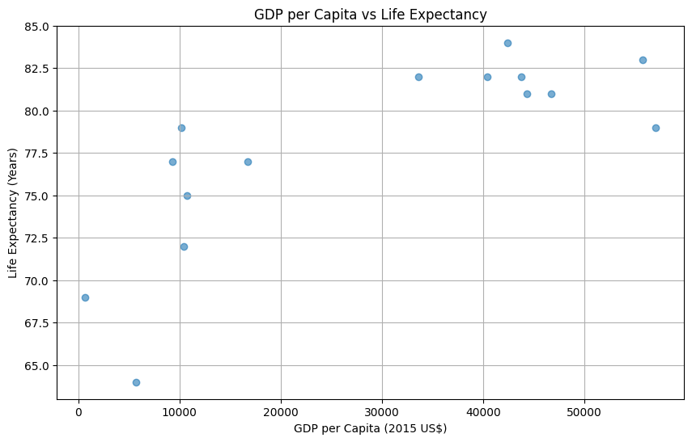

```python
# @title
import pandas as pd
import matplotlib.pyplot as plt

# Load the fixed data
data = pd.read_csv('gdp_life_expectancy_fixed.csv')

# Plot
plt.figure(figsize=(10, 6))
plt.scatter(data['GDP per capita (constant 2015 US$)'], data['Life expectancy at birth (years)'], alpha=0.6)
plt.title('GDP per Capita vs Life Expectancy')
plt.xlabel('GDP per Capita (2015 US$)')
plt.ylabel('Life Expectancy (Years)')
plt.grid(True)
plt.show()
```

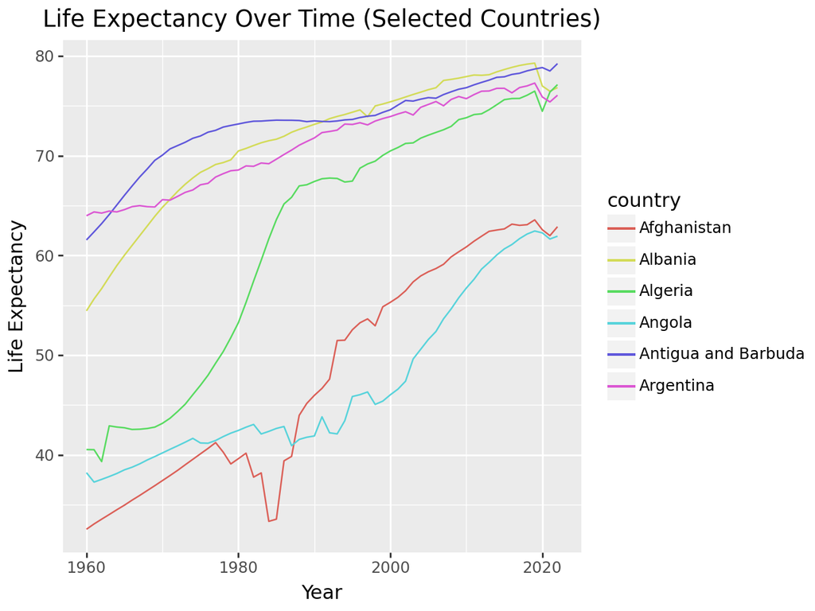

```python
time_series = metadata[['country', 'year', 'Life expectancy at birth, total (years)']].dropna()

selected_countries = time_series['country'].value_counts().head(6).index.tolist()
time_series = time_series[time_series['country'].isin(selected_countries)]

line_plot = (
    ggplot(time_series, aes(x='year', y='Life expectancy at birth, total (years)', color='country')) +
    geom_line() +
    labs(title='Life Expectancy Over Time (Selected Countries)', x='Year', y='Life Expectancy')
)
line_plot
```

## Conclusion

This report highlights significant inequalities in access to healthcare services and child health outcomes across the world. While some countries have made steady progress, others continue to face critical challenges. The data underscores the urgent need for targeted interventions, global cooperation, and sustained investment in healthcare infrastructure to ensure that every child has the opportunity for a healthy start in life.

## Reference

UNICEF (2024) Child Vulnerability Indicators.

World Bank (2024) World Development Indicators.

United Nations (2023) Sustainable Development Goals.